# The Macroeconomic Effects of Oil Supply News Shocks in The USA

Author: Morteza Motegh

# 1. Introduction

The interaction between oil prices and macroeconomic dynamics has long been a source of interest for economists, policymakers, and industry practitioners. The importance of oil as a key component in production and transportation highlights its importance in economic processes.

In the United States, where oil is an essential component of the industrial and home sectors, changes in oil prices affect not only the energy sector but also a wide range of economic activity. Understanding the informational dynamics surrounding oil supplies is critical in this environment. Announcements and foreknowledge about oil supply frequently predate market reactions, resulting in what are known as **oil supply news shocks**. These informational variance shockwaves, in turn, engage a plethora of macroeconomic variables in a complicated interplay.

Through detailed research spanning the period from January 1975 to December 2022, this paper goes on an adventurous voyage into the macroeconomic effects of oil supply news shocks in the United States. The empirical basis for this research is a deep dissection of data relevant to oil supply surprises, oil supply news shocks, consumer price index, and industrial production index within the specified timetable.

The process begins with the complete setup of a Vector Autoregression (VAR) model that captures the dynamic interrelations between the relevant economic variables. The earlier phase includes a comprehensive determination of the model’s structure, highlighted by selecting of an appropriate lag length, followed by an estimation of the reduced form VAR using the Akaike Information Criterion (AIC) as a guiding metric. As the investigation progresses, it moves into a sophisticated estimation of the triangular VAR model helped by Cholesky decomposition, revealing the complicated network of causality and interactions among the variables under consideration.

The next stage relates to an intensive assessment of the stability of the results in order to ensure a robust and unassailable analytical framework. This includes a detailed evaluation of the coefficient matrices’ eigenvalues to confirm the model’s stability.The way concludes with an IRF analysis, which gives light on the time-path of variables in reaction to shocks, clarifying the temporary and long-term macroeconomic effects of oil supply news shocks.

# 2. Methodology

This section describes the methodology used to analyse the macroeconomic effects of oil supply news shocks in the United States. The investigation begins with the collection of relevant data, which is then followed by an analytical get via the VAR model, ending in a strong statistical analysis confirming the reliability and validity of the conclusions.

## 2.1 Data Aggregation

The primary data used in this analysis ranges from January 1975 to December 2022, and includes key variables such as the Oil Supply Surprise series, the Oil Supply News Shock series, the Consumer Price Index (CPI), and the Industrial Production Index (IPI) for the United States. The dataset is carefully selected to assure accuracy and completeness, establishing the basis for the resulting analytical expedition.

## 2.2 Lag Length Determination

Prior to estimating the VAR model, it is critical to determine the right lag duration to ensure the model’s robustness. The lag length is computed using traditional procedures by minimizing the Akaike Information Criterion (AIC). This step is critical because it establishes a structure for further model estimation while ensuring that the model capture the inherent dynamic of the data.

## 2.3 Estimation of Reduced-Form VAR Model

After determining the optimal lag duration, the investigation moves on to the estimate of the reduced-form VAR model. The VAR model is an effective technique for capturing the dynamic interrelationships between system variables. The reduced-form VAR model is estimated, and the parameters are examined to get insight into the temporal interactions between the variables under consideration.

## 2.4 Estimation of the Triangular VAR Model

To go deeper into the causal interplay among variables, the research moves on to the estimate of the triangular VAR model using Cholesky decomposition. This stage is critical in determining the causal link and the mechanism by which oil supply news shocks echo across the macroeconomic landscape. The Cholesky decomposition allows the identification of orthogonal shocks, allowing for a clear explanation of the variables’ dynamic responses to the shocks.

The reliability and validity of the findings are critical to the success of this investigation. As a result, a thorough statistical study is initiated, which includes: 1. Eigenvalues of the Coefficient Matrices: A thorough examination of the eigenvalues of the coefficient matrices is conducted to ascertain the stability of the VAR model. 2. Impulse Response Function (IRF): An Impulse Response Function (IRF) analysis is performed to trace the response of the variables to shocks over time, providing a vivid depiction of the transient and long-term effects of oil supply news shocks on the U.S. macroeconomy.

# 3. Data Description

The data used in the study ranges from January 1975 to December 2022, and it includes the oil supply surprise series, oil supply news shock series, Consumer Price Index (CPI), and Industrial Production Index (IPI) in the United States. Over the long time under discussion, the data series provide fertile ground for determining the macroeconomic repercussions of oil supply news shock.

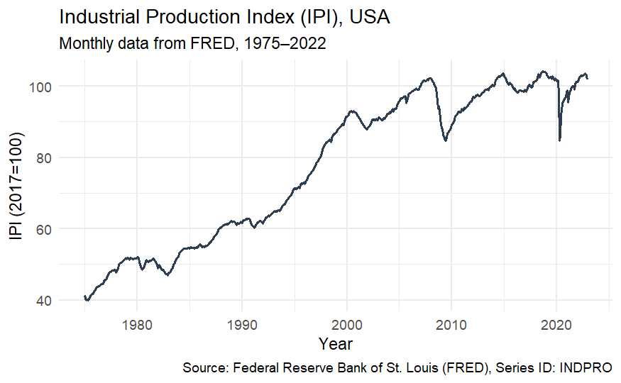

```r
library(quantmod)
library(ggplot2)

# Download IPI from FRED (series ID: INDPRO)
invisible(getSymbols("INDPRO", src = "FRED"))

# Convert to data frame
ipi_data <- data.frame(
  date = index(INDPRO),
  IPI = as.numeric(INDPRO)
)

# Filter 1975–2022
ipi_data <- subset(ipi_data, date >= as.Date("1975-01-01") & date <= as.Date("2022-12-31"))

# Plot
ggplot(ipi_data, aes(x = date, y = IPI)) +
  geom_line(color = "#2C3E50", size = 1) +
  labs(
    title = "Industrial Production Index (IPI), USA",
    subtitle = "Monthly data from FRED, 1975–2022",
    x = "Year",
    y = "IPI (2017=100)",
    caption = "Source: Federal Reserve Bank of St. Louis (FRED), Series ID: INDPRO"
  ) +
  theme_minimal(base_size = 14)
```

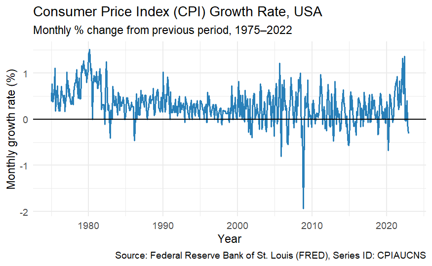

```r
library(quantmod)
library(ggplot2)

# Download CPI (level)
CPI <- getSymbols("CPIAUCNS", src = "FRED", auto.assign = FALSE)

# Convert to data frame
cpi_data <- data.frame(
  date = index(CPI),
  CPI = as.numeric(CPI)
)

# Compute monthly growth rate (%) — difference in logs * 100
cpi_data$CPI_growth <- c(NA, diff(log(cpi_data$CPI)) * 100)

# Filter 1975–2022
cpi_data <- subset(cpi_data, date >= as.Date("1975-01-01") & date <= as.Date("2022-12-31"))

# Plot growth rate
ggplot(cpi_data, aes(x = date, y = CPI_growth)) +
  geom_line(color = "#2980B9", size = 0.9) +
  geom_hline(yintercept = 0, color = "black", linewidth = 0.6) +
  labs(
    title = "Consumer Price Index (CPI) Growth Rate, USA",
    subtitle = "Monthly % change from previous period, 1975–2022",
    x = "Year",
    y = "Monthly growth rate (%)",
    caption = "Source: Federal Reserve Bank of St. Louis (FRED), Series ID: CPIAUCNS"
  ) +
  theme_minimal(base_size = 14)
```